# Quantification of follow-up: code accompanying paper

Kaspar Rufibach, on behalf of follow-up quantification taks force of the oncology estimand WG

Last change: 30th Mai 2022

# 1 Background

Code for the paper Rufibach et al. (2022) written by the “follow-up quantification” task force of the oncology estimand WG.

# 2 Purpose of this document

This R markdown file provides easy accessible code to compute all the quantifiers for follow-up. The github repository where this document is hosted is available [here](https://github.com/numbersman77/quantFU).

To illustrate the functions all clinical trial data in this file is simulated. In the paper, the PH examples uses real data.

# 3 Setup

## 3.1 Packages

```r
# --------------------------------------------------------------
# packages
# --------------------------------------------------------------
packs <- c("survival", "rpact", "survRM2")
for (i in 1:length(packs)){library(packs[i], character.only = TRUE)}
```

## 3.2 Functions

Below all functions are defined.

- `quantifyFU`: This function provides all the seven methods described in the paper draft.
- `plot.qfu`: Plot the distributions from which medians are computed.

```r
# --------------------------------------------------------------
# functions
# --------------------------------------------------------------

# function to compute all the different variants of follow-up quantification
quantifyFU <- function(rando, event_time, event_type, ccod){

  ## =================================================================
  ## compute all FU measures
  ## =================================================================

  # input arguments:
  # - rando: date of randomization
  # - event_time: time to event or time to censoring
  # - event_type: 0 = event, 1 = lost to FU, 2 = administratively censored
  # - ccod: clinical cutoff date

  require(survival)

  n <- length(rando)

  # objects to collect distributions
  res <- NULL

  # indicator for lost to follow up
  ltfu_cens <- as.numeric(event_type == 1)

  # indicator for administratively censored
  admin_cens <- as.numeric(event_type == 2)

  # usual censoring indicator: 0 = censored (for whatever reason), 1 = event
  primary_event <- as.numeric(event_type == 0)

  # indicator for censoring
  event_time_cens <- as.numeric(primary_event == 0)

  # observation time regardless of censoring
  ecdf1 <- as.list(environment(ecdf(event_time)))
  res[[1]] <- cbind(ecdf1$x, 1 - ecdf1$y)
  m1 <- median(event_time)

  # observation time for those event-free
  d2 <- event_time[event_time_cens == 1]
  ecdf2 <- as.list(environment(ecdf(d2)))
  res[[2]] <- cbind(ecdf2$x, 1 - ecdf2$y)
  m2 <- median(d2)

  # time to censoring
  so3 <- survfit(Surv(event_time, event_time_cens) ~ 1)
  res[[3]] <- so3
  m3 <- summary(so3)$table["median"]

  # time to CCOD, potential followup
  pfu <- as.numeric((ccod - rando) / 365.25 * 12)
  ecdf4 <- as.list(environment(ecdf(pfu)))
  res[[4]] <- cbind(ecdf4$x, 1 - ecdf4$y)
  m4 <- median(pfu)

  # known function time
  m5 <- rep(NA, n)
  m5[event_time_cens == 1] <- event_time[event_time_cens == 1]
  m5[primary_event == 1] <- pfu[primary_event == 1]
  ecdf5 <- as.list(environment(ecdf(m5)))
  res[[5]] <- cbind(ecdf5$x, 1 - ecdf5$y)
  m5 <- median(m5)

  # Korn's potential follow-up time
  spfu <- sort(pfu)
  pt <- rep(NA, n)
  for (i in 1:n){

    # timepoint at which we compute potential followup (t' in Schemper et al)
    t <- spfu[i]

    # proportion with pfu > t
    pet <- mean(spfu > t)

    # time to LTFU
    so6 <- survfit(Surv(event_time, ltfu_cens) ~ 1, subset = (pfu >= t))
    pltet <- ifelse(max(so6$time > t) == 0, 0, so6$surv[so6$time > t][1])

    pt[i] <- pltet * pet
  }

  res[[6]] <- cbind(spfu, pt)

  # now take the median of the distribution, see plot(t, pt, type = "s")
  m6 <- max(spfu[pt >= 0.5])

  # Potential follow-up considering events
  m7 <- rep(NA, n)
  m7[event_time_cens == 1] <- pfu[event_time_cens == 1]
  m7[primary_event == 1] <- event_time[primary_event == 1]
  ecdf7 <- as.list(environment(ecdf(m7)))
  res[[7]] <- cbind(ecdf7$x, 1 - ecdf7$y)
  m7 <- median(m7)

  # summarize results for medians
  dat <- matrix(NA, nrow = 7, ncol = 1)
  dat[, 1] <- c(m1, m2, m3, m4, m5, m6, m7)
  rownames(dat) <- c("Observation time regardless of censoring", "Observation time for those event-free",
                     "Time to censoring", "Time to CCOD", "Known function time", "Korn potential follow-up",
                     "Potential follow-up considering events")
  colnames(dat) <- "median"

  output <- list("medians" = dat, "distributions" = res)
  class(output) <- "qfu"
  return(output)
}

# function to plot distributions of various quantifiers
plot.qfu <- function(x, which = 1:7, median = TRUE){

  dat <- x$distributions

  par(las = 1)
  plot(0, 0, type = "n", xlim = c(0, 1.05 * max(dat[[1]][, 1])), ylim = c(0, 1), xlab = "time-to-event endpoint", ylab = "probability",
       main = "Distributions used for quantification of follow-up")
  if (3 %in% which){lines(dat[[3]], col = 3, conf.int = FALSE)}
  which <- which[which != 3]
  for (i in which){lines(dat[[i]], col = i)}

  if(isTRUE(median)){abline(h = 0.5, col = grey(0.5), lwd = 2)}

  legend("bottomleft", rownames(x$medians)[which], lty = 1, col = (1:7)[which], bty = "n", lwd = 2)
}

# compute value of KM estimate and CI
confIntKM_t0 <- function(time, event, t0, conf.level = 0.95){

  alpha <- 1 - conf.level

  # compute ci according to the formulas in Huesler and Zimmermann, Chapter 21
  obj <- survfit(Surv(time, event) ~ 1, conf.int = 1 - alpha, conf.type = "plain", type = "kaplan", error = "greenwood", conf.lower = "peto")
  St <- summary(obj)$surv
  t <- summary(obj)$time
  n <- summary(obj)$n.risk
  res <- matrix(NA, nrow = length(t0), ncol = 3)

  for (i in 1:length(t0)){
    ti <- t0[i]
    if (min(t) > ti){res[i, ] <- c(1, NA, NA)}
    if (min(t) <= ti){
        if (ti %in% t){res[i, ] <- rep(NA, 3)} else {
            Sti <- min(St[t < ti])
            nti <- min(n[t < ti])
            Var.peto <- Sti ^ 2 * (1 - Sti) / nti
            Cti <- exp(qnorm(1 - alpha / 2) * sqrt(Var.peto) / (Sti ^ (3 / 2) * (1 - Sti)))
            ci.km <- c(Sti / ((1 - Cti) * Sti + Cti), Cti * Sti / ((Cti - 1) * Sti + 1))
            res[i, ] <- c(Sti, ci.km)}
    } # end if
  } # end for

  res <- cbind(t0, res)
  dimnames(res)[[2]] <- c("t0", "S at t0", "lower.ci", "upper.ci")
  return(res)
}

# bootstrap survival data
bootSurvivalSample <- function(surv.obj, n, M = 1000, track = TRUE){

     # bootstrap right-censored survival data according to Efron (1981)
     # see Akritas (1986) for details
     # surv.obj: Surv object to sample from
     # n: sample size for samples to be drawn
     # M: number of samples

     n.surv <- nrow(surv.obj)
     res.mat <- data.frame(matrix(NA, ncol = M, nrow = n))

     for (i in 1:M){
          ind <- sample(1:n.surv, size = n, replace = TRUE)
          res.mat[, i] <- surv.obj[ind]
          if (track){print(paste("sample ", i, " of ", M, " done", sep = ""))}
     }

     return(res.mat)
}

# compute value and CI for difference of survival probabilities at milestone, via bootstrap
confIntMilestoneDiff <- function(time, event, group, t0, M = 10 ^ 3, conf.level = 0.95){

  ind <- (group == levels(group)[1])
  s.obj1 <- Surv(time[ind], event[ind])
  s.obj2 <- Surv(time[!ind], event[!ind])
  n1 <- sum(ind)
  n2 <- sum(!ind)

  res1 <- bootSurvivalSample(surv.obj = s.obj1, n = n1, M = M, track = FALSE)
  res2 <- bootSurvivalSample(surv.obj = s.obj2, n = n2, M = M, track = FALSE)

  boot.diff1 <- rep(NA, M)
  boot.diff2 <- boot.diff1

  for (i in 1:M){

    # based on KM
    t1km <- confIntKM_t0(time = as.matrix(res1[, i])[, "time"], event = as.matrix(res1[, i])[, "status"], t0, conf.level = 0.95)[2]
    t2km <- confIntKM_t0(time = as.matrix(res2[, i])[, "time"], event = as.matrix(res2[, i])[, "status"], t0, conf.level = 0.95)[2]
    boot.diff1[i] <- t1km - t2km

    # based on exponential fit
    r1 <- exp(- coef(survreg(res1[, i] ~ 1, dist = "exponential")))
    t1 <- 1 - pexp(t0, rate = r1)

    r2 <- exp(- coef(survreg(res2[, i] ~ 1, dist = "exponential")))
    t2 <- 1 - pexp(t0, rate = r2)

    boot.diff2[i] <- t1 - t2

  }

  # from bootstrap sample of differences just take symmetric quantiles to get CI for difference
  alpha <- 1 - conf.level
  ci1 <- quantile(boot.diff1, probs = c(alpha / 2, 1 - alpha / 2), na.rm = TRUE)
  ci2 <- quantile(boot.diff2, probs = c(alpha / 2, 1 - alpha / 2), na.rm = TRUE)

  res <- list("km" = ci1, "exponential" = ci2)
  return(res)
}

# compute the extreme limits as described by Betensky
stabilityKM <- function(time, event){

  ind <- (event == 0)
  maxevent <- max(time[event == 1])

  # extreme scenarios (not precisely) according to Betensky (2015)
  # lower bound: every censored patient has event at censoring date
  t_low <- time
  c_low <- event
  c_low[ind] <- 1

  # upper bound: every censored observation has censoring time equal to maximum event time
  t_up <- time
  t_up[ind & (time < maxevent)] <- maxevent
  c_up <- event

  # collect results
  res <- list("t_low" = t_low, "c_low" = c_low, "t_up" = t_up, "c_up" = c_up)
  return(res)
}
```

# 4 Example: Proportional hazards

## 4.1 Simulate a clinical trial with time-to-event endpoint using `rpact`

A clinical trial with very similar properties as the Gallium data in Rufibach et al. (2022) is simulated using `rpact` Wassmer and Pahlke (2021).

```r
# simulate a clinical trial using rpact
# time unit is months
design <- getDesignGroupSequential(informationRates = 1,
   typeOfDesign = "asOF", sided = 1, alpha = 0.025, beta = 0.2)

simulationResult <- getSimulationSurvival(design,
    lambda2 = log(2) / 60, hazardRatio = 0.75,
    dropoutRate1 = 0.025, dropoutRate2 = 0.025,
    dropoutTime = 12,
    accrualTime = 0:6,
    accrualIntensity = 6 * 1:7,
    plannedEvents = 350,
    directionUpper = FALSE,
    maxNumberOfSubjects = 1000,
    maxNumberOfIterations = 1,
    maxNumberOfRawDatasetsPerStage = 1,
    seed = 2021)

# retrieve dataset
simdat <- getRawData(simulationResult)

# create variable with randomization dates
# note that addition / subtraction of date objects happens in days
# --> multiplication by 365.25 / 12 ~= 30 below
day0 <- as.Date("2016-01-31", origin = "1899-12-30")
rando <- day0 + simdat$accrualTime * 365.25 / 12
pfs <- simdat$timeUnderObservation

# event type variable: 0 = event, 1 = lost to FU, 2 = administratively censored
event_type <- rep(NA, nrow(simdat))
event_type[simdat$event == TRUE] <- 0
event_type[simdat$event == FALSE & simdat$dropoutEvent == TRUE] <- 1
event_type[simdat$event == FALSE & simdat$dropoutEvent == FALSE] <- 2

# PFS event
pfsevent <- as.numeric(event_type == 0)

# treatment arm
arm <- factor(simdat$treatmentGroup, levels = 1:2, labels = c("G", "R"))

# define clinical cutoff date based on simulation result
ccod <- day0 + simdat$observationTime[1] * 365.25 / 12

# check
so1 <- summary(coxph(Surv(pfs, pfsevent) ~ arm))
so1
```

```
## Call:
## coxph(formula = Surv(pfs, pfsevent) ~ arm)
##
##   n= 1000, number of events= 350
##
##        coef exp(coef) se(coef)     z Pr(>|z|)
## armR 0.2351    1.2650   0.1073 2.191   0.0285 *
## ---
## Signif. codes:  0 '***' 0.001 '**' 0.01 '*' 0.05 '.' 0.1 ' ' 1
##
##      exp(coef) exp(-coef) lower .95 upper .95
## armR     1.265     0.7905     1.025     1.561
##
## Concordance= 0.528  (se = 0.014 )
## Likelihood ratio test= 4.82  on 1 df,   p=0.03
## Wald test            = 4.8  on 1 df,   p=0.03
## Score (logrank) test = 4.82  on 1 df,   p=0.03
```

Plot the Kaplan-Meier estimates:

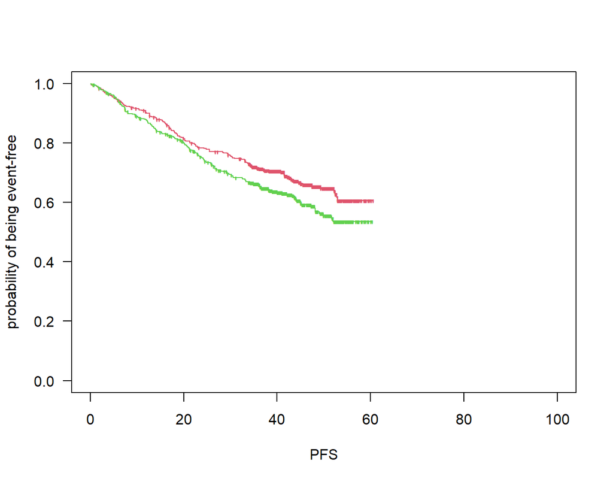

```r
par(las = 1)
plot(survfit(Surv(pfs, pfsevent) ~ arm), col = 2:3, mark = "'", lty = 1, xlim = c(0, 100),
     xlab = "PFS", ylab = "probability of being event-free")
```

## 4.2 Precision

Compute survival probabilities, their differences and confidence intervals at milestones.

```r
ms <- c(36, 48)
msR1 <- confIntKM_t0(time = pfs[arm == "R"], event = pfsevent[arm == "R"], t0 = ms, conf.level = 0.95)
msG1 <- confIntKM_t0(time = pfs[arm == "G"], event = pfsevent[arm == "G"], t0 = ms, conf.level = 0.95)
msR1
```

```
##      t0   S at t0  lower.ci  upper.ci
## [1,] 36 0.6625629 0.6054758 0.7152741
## [2,] 48 0.5870704 0.4922056 0.6758830
```

```r
msG1
```

```
##      t0   S at t0  lower.ci  upper.ci
## [1,] 36 0.7149897 0.6622073 0.7624827
## [2,] 48 0.6536542 0.5662833 0.7317616
```

```r
# differences
ms1d1 <- confIntMilestoneDiff(time = pfs, event = pfsevent, group = arm,
                             t0 = ms[1], M = 10 ^ 3, conf.level = 0.95)$km
ms2d1 <- confIntMilestoneDiff(time = pfs, event = pfsevent, group = arm,
                              t0 = ms[2], M = 10 ^ 3, conf.level = 0.95)$km
ms1d1
```

```
##         2.5%        97.5%
## -0.003376164  0.114936362
```

```r
ms2d1
```

```
##          2.5%         97.5%
## -0.0007250327  0.1350419043
```

## 4.3 Quantification of follow-up using various methods

Now let us apply the above functions:

```r
fu <- quantifyFU(rando = rando, event_time = pfs, event_type = event_type, ccod = ccod)

# medians of all these distributions:
fu$medians
```

```
##                                            median
## Observation time regardless of censoring 38.28363
## Observation time for those event-free    42.87887
## Time to censoring                        44.05744
## Time to CCOD                             45.78363
## Known function time                      44.55744
## Korn potential follow-up                 44.15268
## Potential follow-up considering events   40.31934
```

Plot distributions:

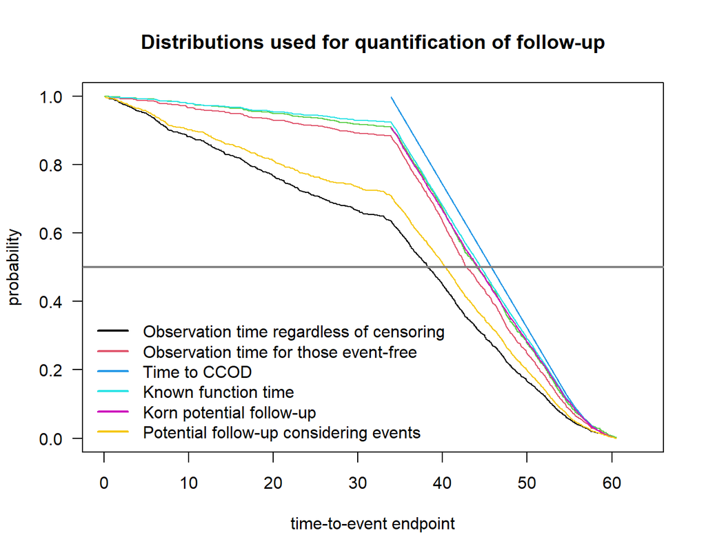

```r
plot(fu)
```

# 5 Example: delayed separation

## 5.1 Simulate a clinical trial with time-to-event endpoint using `rpact`

```r
# Simulation assuming a delayed treatment effect
alpha <- 0.05
beta <- 0.2
design <- getDesignGroupSequential(informationRates = 1, typeOfDesign = "asOF", sided = 1,
                                   alpha = alpha / 2, beta = beta)

piecewiseSurvivalTime <- c(0, 12)
baserate <- log(2) / 60
hr_nph <- 0.65
dropoutRate <- 0.025
dropoutTime <- 12
accrualTime <- 0:6
accrualIntensity <- 6 * 1:7
plannedEvents <- 389
maxNumberOfSubjects <- 1000
maxNumberOfIterations <- 10 ^ 3

simulationResultNPH <- getSimulationSurvival(design,
                                             piecewiseSurvivalTime = piecewiseSurvivalTime,
                                             lambda2 = c(baserate, baserate),
                                             lambda1 = c(baserate, hr_nph * baserate),
                                             dropoutRate1 = dropoutRate,
                                             dropoutRate2 = dropoutRate, dropoutTime = dropoutTime,
                                             accrualTime = accrualTime,
                                             accrualIntensity = accrualIntensity,
                                             plannedEvents = plannedEvents,
                                             directionUpper = FALSE,
                                             maxNumberOfSubjects = maxNumberOfSubjects,
                                             maxNumberOfIterations = maxNumberOfIterations,
                                             maxNumberOfRawDatasetsPerStage = 10 ^ 4,
                                             seed = 2021)

# power for logrank test
simulationResultNPH$overallReject
```

```
## [1] 0.805
```

```r
# access raw simulation data
simdat <- getRawData(simulationResultNPH)

# extract simulation run 1 for example in paper
simpick <- 1
simdat_run1 <- subset(simdat, iterationNumber == simpick)

# median time-to-dropout
med_do <- - log(2) / log((1- dropoutRate)) * dropoutTime

# create variable with randomization dates
# note that addition / subtraction of date objects happens in days
# --> multiplication by 365.25 / 12 ~= 30 below
day0_nph <- as.Date("2016-01-31", origin = "1899-12-30")
rando_nph <- day0_nph + simdat_run1$accrualTime * 365.25 / 12
pfs1_nph <- simdat_run1$timeUnderObservation

# event type variable: 0 = event, 1 = lost to FU, 2 = administratively censored
event_type_nph <- rep(NA, nrow(simdat_run1))
event_type_nph[simdat_run1$event == TRUE] <- 0
event_type_nph[simdat_run1$event == FALSE & simdat_run1$dropoutEvent == TRUE] <- 1
event_type_nph[simdat_run1$event == FALSE & simdat_run1$dropoutEvent == FALSE] <- 2

# PFS event
pfsevent1_nph <- as.numeric(event_type_nph == 0)

# treatment arm
arm_nph <- factor(simdat_run1$treatmentGroup, levels = 1:2, labels = c("G", "R"))

# define clinical cutoff date based on simulation result
ccod1_nph <- day0_nph + simdat_run1$observationTime[1] * 365.25 / 12
```

Plot Kaplan-Meier estimates:

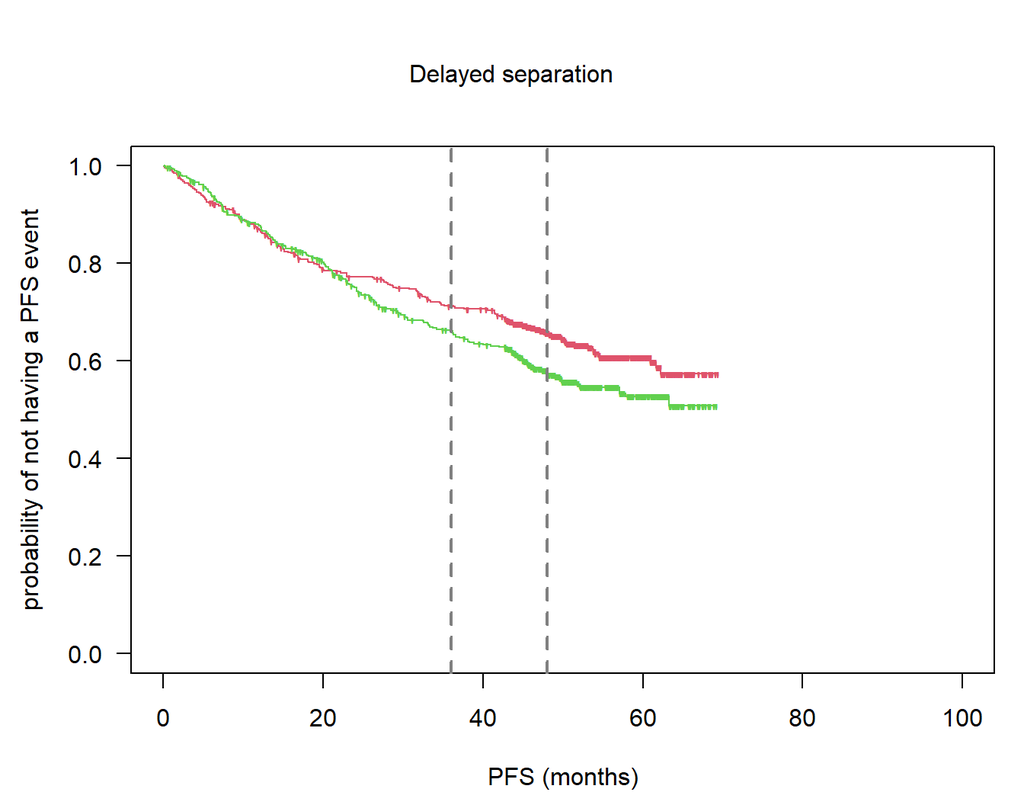

```r
par(las = 1, mar = c(4.5, 4.5, 2, 1), oma = c(0, 0, 3, 0))

so1_nph <- survfit(Surv(pfs1_nph, pfsevent1_nph) ~ arm_nph)
plot(so1_nph, col = 2:3, mark = "'", lty = 1, xlim = c(0, 100), xlab = "PFS (months)",
     ylab = "probability of not having a PFS event")

abline(v = ms, col = grey(0.5), lwd = 2, lty = 2)

# title
mtext("Delayed separation", 3, line = 0, outer = TRUE)
```

## 5.2 Precision

Compute survival probabilities, their differences and confidence intervals at milestones.

```r
ms <- c(36, 48)
msR1_nph <- confIntKM_t0(time = pfs1_nph[arm == "R"], event = pfsevent1_nph[arm == "R"],
                         t0 = ms, conf.level = 0.95)
msG1_nph <- confIntKM_t0(time = pfs1_nph[arm == "G"], event = pfsevent1_nph[arm == "G"],
                         t0 = ms, conf.level = 0.95)
msR1_nph
```

```
##      t0   S at t0  lower.ci  upper.ci
## [1,] 36 0.6626743 0.6066027 0.7145152
## [2,] 48 0.5801327 0.5109735 0.6462818
```

```r
msG1_nph
```

```
##      t0   S at t0  lower.ci  upper.ci
## [1,] 36 0.7125514 0.6617708 0.7584903
## [2,] 48 0.6571132 0.5948195 0.7144277
```

```r
# differences
ms1d1_nph <- confIntMilestoneDiff(time = pfs1_nph, event = pfsevent1_nph, group = arm,
                             t0 = ms[1], M = 10 ^ 3, conf.level = 0.95)$km
ms2d1_nph <- confIntMilestoneDiff(time = pfs1_nph, event = pfsevent1_nph, group = arm,
                              t0 = ms[2], M = 10 ^ 3, conf.level = 0.95)$km
ms1d1_nph
```

```
##         2.5%        97.5%
## -0.007217885  0.105350010
```

```r
ms2d1_nph
```

```
##       2.5%      97.5%
## 0.01560682 0.13856650
```

## 5.3 Stability

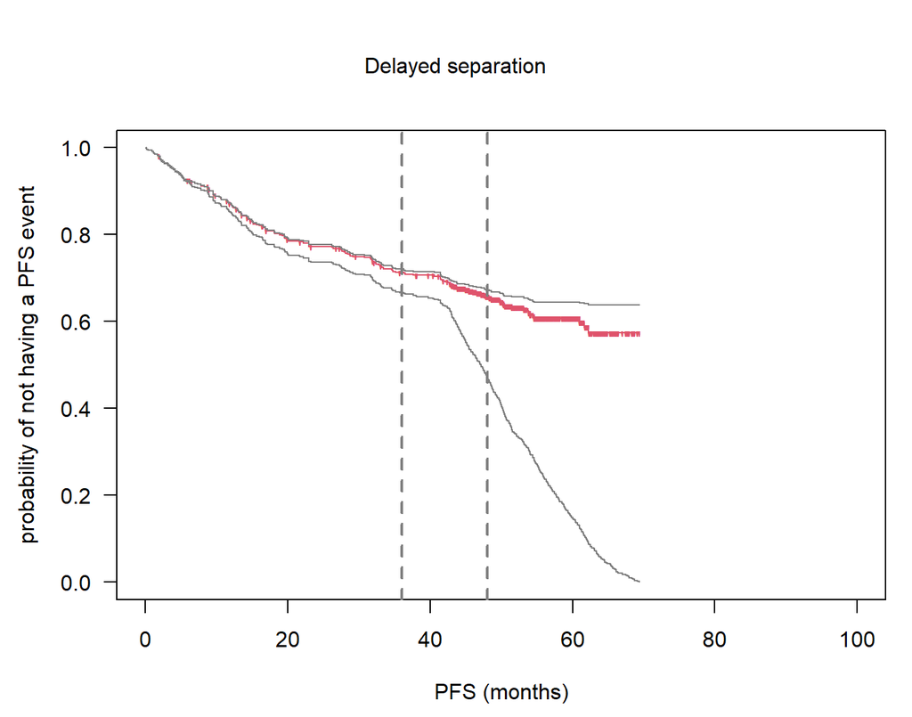

```r
par(las = 1, mar = c(4.5, 4.5, 2, 1), oma = c(0, 0, 3, 0))

so2_nph <- survfit(Surv(pfs1_nph, pfsevent1_nph) ~ 1, subset = (arm_nph == "G"))
plot(so2_nph, col = 2, mark = "'", lty = 1, xlim = c(0, 100), xlab = "PFS (months)",
     ylab = "probability of not having a PFS event", conf.int = FALSE)

abline(v = ms, col = grey(0.5), lwd = 2, lty = 2)

# title
mtext("Delayed separation", 3, line = 0, outer = TRUE)

# add Betensky's scenarios
stab_del_t <- stabilityKM(time = pfs1_nph[arm_nph == "G"], pfsevent1_nph[arm_nph == "G"])
stab_del_c <- stabilityKM(time = pfs1_nph[arm_nph == "R"], pfsevent1_nph[arm_nph == "R"])

# lower
so2_nph_low <- survfit(Surv(stab_del_t$t_low, stab_del_t$c_low) ~ 1)
lines(so2_nph_low, col = grey(0.5), lty = 1, conf.int = FALSE)

# upper
so2_nph_up <- survfit(Surv(stab_del_t$t_up, stab_del_t$c_up) ~ 1)
lines(so2_nph_up, col = grey(0.5), lty = 1, conf.int = FALSE)
```

## 5.4 Power for RMST

```r
# restriction timepoint for RMST
tau <- NULL   # use minimum of the two last observed times in each arm

# compute RMST for every simulated dataset
# use simulationResultNPH from p30

rmst_est <- rep(NA, maxNumberOfIterations)
rmst_pval <- rmst_est
logrank_pval <- rmst_est

for (i in 1:maxNumberOfIterations){
  sim.i <- subset(simdat, iterationNumber == i)

  time <- sim.i$timeUnderObservation
  event <- as.numeric(sim.i$event)
  arm <- factor(as.numeric(sim.i$treatmentGroup == 1))

  rmst <- rmst2(time = time, status = event, arm = arm, tau = NULL)
  if (i == 1){rmst_sim1 <- rmst}

  # we look at difference in RMST between arms
  rmst_est[i] <- rmst$unadjusted.result[1, "Est."]
  rmst_pval[i] <- rmst$unadjusted.result[1, "p"]

  # logrank p-value (score test from Cox regression)
  logrank_pval[i] <- summary(coxph(Surv(time, event) ~ arm))$sctest["pvalue"]
}

# empirical power
rmst_power <- mean(rmst_pval <= 0.05)
rmst_power
```

```
## [1] 0.692
```

```r
mean(logrank_pval <= 0.05)
```

```
## [1] 0.805
```

```r
simulationResultNPH$overallReject
```

```
## [1] 0.805
```

## 5.5 Quantification of follow-up using various methods

Now let us apply the above functions:

```r
# compute various follow-up quantities
fu1_nph <- quantifyFU(rando = rando_nph, event_time = pfs1_nph,
                      event_type = event_type_nph, ccod = ccod1_nph)
fu1med_nph <- fu1_nph$medians

# medians of all these distributions:
fu1med_nph
```

```
##                                            median
## Observation time regardless of censoring 45.47638
## Observation time for those event-free    51.46786
## Time to censoring                        52.84881
## Time to CCOD                             54.64643
## Known function time                      53.31310
## Korn potential follow-up                 52.80119
## Potential follow-up considering events   48.07205
```

Plot distributions:

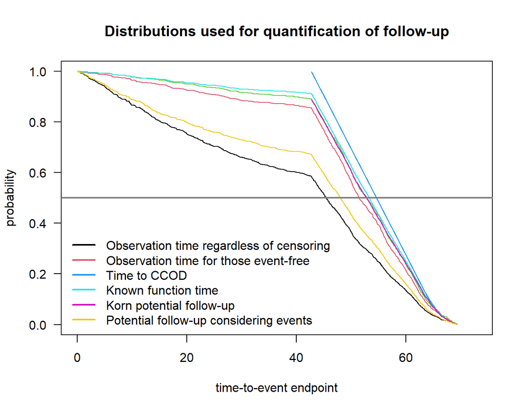

```r
plot(fu1_nph)
```

# References

Rufibach, K., L. Grinsted, J. Li, Y. Shentu, J. Weber, C. Zheng, and J. Zhou. 2022. “Quantification of Follow-up Time in Oncology Clinical Trials with a Time-to-Event Endpoint: Asking the Right Questions.” Oncology estimand working group.

Wassmer, Gernot, and Friedrich Pahlke. 2021. *Rpact: Confirmatory Adaptive Clinical Trial Design and Analysis*. https://CRAN.R-project.org/package=rpact.